# Bizmetrics Capstone

Mai Nguyen

11/11/2021

## Get data

```r
ws_data <- read.csv("C:/Users/Mai/OneDrive/Courses/spec_business_analytics_excel_to_sql/course_5_capstone_watershed_short_term_rentals/week 2 get data/ws_data.csv")
```

## Clean up names

```r
ws_data <- ws_data %>%
  rename(
    p90 = percentile_90th_price,
    p10 = percentile_10th_price,
    nights_per_year = count...,
    st_nightly = sample_nightly_rent_price,
    lt_monthly = current_monthly_rent)
head(ws_data)
```

```
##   ws_property_id location property_type lt_monthly p10 p90 st_nightly
## 1             W1    L9531            R6       1060 114 153        148
## 2            W10    L9533            R6       1200 111 149        133
## 3           W100    L1944            R2       3300 108 610        372
## 4           W101   L15257            R2       1400 178 533        302
## 5           W102   L15257            R6       2000 221 617        429
## 6           W103   L15257           R10       1600 202 646        380
##   nights_per_year occ_rate          city state zipcode apt_house num_bedrooms
## 1              59     0.16   Chapel Hill    NC   27514 apartment            2
## 2             127     0.35   Chapel Hill    NC   27517 apartment            2
## 3             145     0.40 San Francisco    CA   94129 apartment            1
## 4             133     0.36        Austin    TX   78702 apartment            1
## 5             150     0.41        Austin    TX   78702 apartment            2
## 6             150     0.41        Austin    TX   78702     house            1
##   kitchen shared
## 1       Y      N
## 2       Y      N
## 3       Y      N
## 4       Y      N
## 5       Y      N
## 6       Y      N
```

Note on naming convention: ST already means “nightly” and LT means “monthly” or yearly contract, but I’m just getting familiar with this topic so I keep the redundant names to remind myself of what they mean.

## Normalize data

Here we normalize example ST rate to percentile using the 10th and 90th percentile prices of its corresponding location. We add 0.1 to ensure that the normalized data falls between 10th and 90th percentiles again.

```r
ws_data <- ws_data %>%
  mutate(
    st_nightly_norm = 0.1 + 0.8 * (st_nightly - p10) / (p90 - p10),
    lt_annual_rev = lt_monthly * 12 * 0.973
  )
head(ws_data)
```

```
##   ws_property_id location property_type lt_monthly p10 p90 st_nightly
## 1             W1    L9531            R6       1060 114 153        148
## 2            W10    L9533            R6       1200 111 149        133
## 3           W100    L1944            R2       3300 108 610        372
## 4           W101   L15257            R2       1400 178 533        302
## 5           W102   L15257            R6       2000 221 617        429
## 6           W103   L15257           R10       1600 202 646        380
##   nights_per_year occ_rate          city state zipcode apt_house num_bedrooms
## 1              59     0.16   Chapel Hill    NC   27514 apartment            2
## 2             127     0.35   Chapel Hill    NC   27517 apartment            2
## 3             145     0.40 San Francisco    CA   94129 apartment            1
## 4             133     0.36        Austin    TX   78702 apartment            1
## 5             150     0.41        Austin    TX   78702 apartment            2
## 6             150     0.41        Austin    TX   78702     house            1
##   kitchen shared st_nightly_norm lt_annual_rev
## 1       Y      N       0.7974359      12376.56
## 2       Y      N       0.5631579      14011.20
## 3       Y      N       0.5207171      38530.80
## 4       Y      N       0.3794366      16346.40
## 5       Y      N       0.5202020      23352.00
## 6       Y      N       0.4207207      18681.60
```

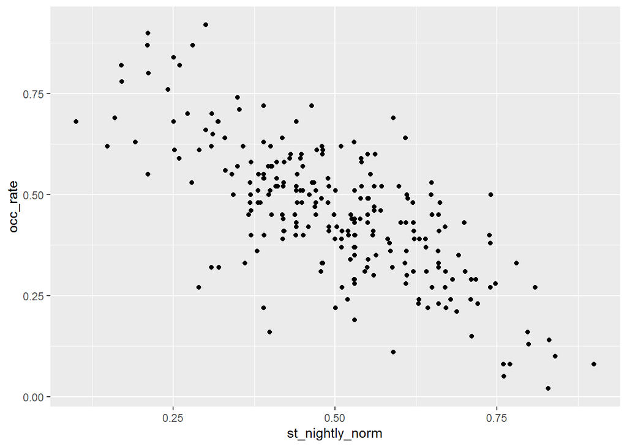

```r
ggplot(data = ws_data) +
  geom_point(aes(x = st_nightly_norm, y = occ_rate))
```

## Simple linear regression for normalized ST rate v. occupancy rate

Occupancy rate is negatively correlated with normalized rental rates, and the relationship is statistically significant.

```r
mod1 <- lm(occ_rate ~ st_nightly_norm, data = ws_data)
summary(mod1)
```

```
##
## Call:
## lm(formula = occ_rate ~ st_nightly_norm, data = ws_data)
##
## Residuals:
##      Min       1Q   Median       3Q      Max
## -0.37493 -0.06930  0.00154  0.07194  0.30655
##
## Coefficients:
##                 Estimate Std. Error t value Pr(>|t|)
## (Intercept)      0.85167    0.02560   33.27   <2e-16 ***
## st_nightly_norm -0.79359    0.04922  -16.12   <2e-16 ***
## ---
## Signif. codes:  0 '***' 0.001 '**' 0.01 '*' 0.05 '.' 0.1 ' ' 1
##
## Residual standard error: 0.114 on 242 degrees of freedom
## Multiple R-squared:  0.5179, Adjusted R-squared:  0.5159
## F-statistic:   260 on 1 and 242 DF,  p-value: < 2.2e-16
```

```r
alpha <- mod1$coefficients[1]
alpha
```

```
## (Intercept)
##   0.8516725
```

```r
beta <- mod1$coefficients[2]
beta
```

```
## st_nightly_norm
##      -0.7935938
```

## Predicting occupancy rate using linear model

```r
ws_data <- ws_data %>%
  mutate(
    # pred_occ_rate = alpha + beta * norm_rental_rate,
    pred_occ_rate = predict(mod1)
    )
head(ws_data)
```

```
##   ws_property_id location property_type lt_monthly p10 p90 st_nightly
## 1             W1    L9531            R6       1060 114 153        148
## 2            W10    L9533            R6       1200 111 149        133
## 3           W100    L1944            R2       3300 108 610        372
## 4           W101   L15257            R2       1400 178 533        302
## 5           W102   L15257            R6       2000 221 617        429
## 6           W103   L15257           R10       1600 202 646        380
##   nights_per_year occ_rate          city state zipcode apt_house num_bedrooms
## 1              59     0.16   Chapel Hill    NC   27514 apartment            2
## 2             127     0.35   Chapel Hill    NC   27517 apartment            2
## 3             145     0.40 San Francisco    CA   94129 apartment            1
## 4             133     0.36        Austin    TX   78702 apartment            1
## 5             150     0.41        Austin    TX   78702 apartment            2
## 6             150     0.41        Austin    TX   78702     house            1
##   kitchen shared st_nightly_norm lt_annual_rev pred_occ_rate
## 1       Y      N       0.7974359      12376.56     0.2188324
## 2       Y      N       0.5631579      14011.20     0.4047539
## 3       Y      N       0.5207171      38530.80     0.4384347
## 4       Y      N       0.3794366      16346.40     0.5505540
## 5       Y      N       0.5202020      23352.00     0.4388435
## 6       Y      N       0.4207207      18681.60     0.5177912
```

## Optimize rental rate and occupancy rate

Find nightly rental rate (normalized) that maximize revenue for that property, using the predicted occupancy rate based on alpha and beta. If nightly rental rate is less than 10-th percentile of the sample rate, use the 10-th percentile instead.

```r
ws_data <- ws_data %>%
  mutate(
    r = p90-p10,
    optim_st_raw = ((beta*(p10-r/8)) / (1.25*r) - alpha)*((1.25*r)/(2*beta)),
    optim_st_adj = pmax(optim_st_raw, p10),
    optim_st_rent_norm = 0.8*(optim_st_adj - p10)/r + .1,
    optim_occ_rate = beta * optim_st_rent_norm + alpha
  )
head(ws_data)
```

```
##   ws_property_id location property_type lt_monthly p10 p90 st_nightly
## 1             W1    L9531            R6       1060 114 153        148
## 2            W10    L9533            R6       1200 111 149        133
## 3           W100    L1944            R2       3300 108 610        372
## 4           W101   L15257            R2       1400 178 533        302
## 5           W102   L15257            R6       2000 221 617        429
## 6           W103   L15257           R10       1600 202 646        380
##   nights_per_year occ_rate          city state zipcode apt_house num_bedrooms
## 1              59     0.16   Chapel Hill    NC   27514 apartment            2
## 2             127     0.35   Chapel Hill    NC   27517 apartment            2
## 3             145     0.40 San Francisco    CA   94129 apartment            1
## 4             133     0.36        Austin    TX   78702 apartment            1
## 5             150     0.41        Austin    TX   78702 apartment            2
## 6             150     0.41        Austin    TX   78702     house            1
##   kitchen shared st_nightly_norm lt_annual_rev pred_occ_rate   r optim_st_raw
## 1       Y      N       0.7974359      12376.56     0.2188324  39     80.72137
## 2       Y      N       0.5631579      14011.20     0.4047539  38     78.61313
## 3       Y      N       0.5207171      38530.80     0.4384347 502    359.33664
## 4       Y      N       0.3794366      16346.40     0.5505540 355    304.92532
## 5       Y      N       0.5202020      23352.00     0.4388435 396    351.36317
## 6       Y      N       0.4207207      18681.60     0.5177912 444    371.05870
##   optim_st_adj optim_st_rent_norm optim_occ_rate
## 1     114.0000          0.1000000      0.7723132
## 2     111.0000          0.1000000      0.7723132
## 3     359.3366          0.5005365      0.4544499
## 4     304.9253          0.3860289      0.5453224
## 5     351.3632          0.3633599      0.5633124
## 6     371.0587          0.4046103      0.5305763
```

- Alternatively, use `optim` to find profit maximizing nightly rate:

```r
per_prop <- ws_data[3,]

rev <- function(st_raw, data){
  r <- data$p90 - data$p10
  st_norm <- 0.1 + 0.8*((st_raw - data$p10)/ r)
  pred_occ <- alpha + (beta*st_norm)
  revenue <- (st_raw * pred_occ * 365)
  revenue
}

optim_output <- optim(
  par = 1,
  fn = rev,
  data = per_prop,
  method = "L-BFGS-B",
  control = list(fnscale =-1), # -1 means find max
  lower = per_prop$p10 # anything less than .1 gets set to .1 (if() step in Excel)
    )
optim_output
```

```
## $par
## [1] 359.3366
##
## $value
## [1] 59604.68
##
## $counts
## function gradient
##        7        7
##
## $convergence
## [1] 0
##
## $message
## [1] "CONVERGENCE: REL_REDUCTION_OF_F <= FACTR*EPSMCH"
```

```r
for (i in 1:nrow(ws_data)){
  ws_data[i,'optim_st_adj_2'] <- optim(
    par = 1,
    fn = rev,
    data = ws_data[i,],
    method = "L-BFGS-B",
    control = list(fnscale =-1),
    lower = ws_data[i,'p10'])[1]
  }
head(ws_data)
```

```
##   ws_property_id location property_type lt_monthly p10 p90 st_nightly
## 1             W1    L9531            R6       1060 114 153        148
## 2            W10    L9533            R6       1200 111 149        133
## 3           W100    L1944            R2       3300 108 610        372
## 4           W101   L15257            R2       1400 178 533        302
## 5           W102   L15257            R6       2000 221 617        429
## 6           W103   L15257           R10       1600 202 646        380
##   nights_per_year occ_rate          city state zipcode apt_house num_bedrooms
## 1              59     0.16   Chapel Hill    NC   27514 apartment            2
## 2             127     0.35   Chapel Hill    NC   27517 apartment            2
## 3             145     0.40 San Francisco    CA   94129 apartment            1
## 4             133     0.36        Austin    TX   78702 apartment            1
## 5             150     0.41        Austin    TX   78702 apartment            2
## 6             150     0.41        Austin    TX   78702     house            1
##   kitchen shared st_nightly_norm lt_annual_rev pred_occ_rate   r optim_st_raw
## 1       Y      N       0.7974359      12376.56     0.2188324  39     80.72137
## 2       Y      N       0.5631579      14011.20     0.4047539  38     78.61313
## 3       Y      N       0.5207171      38530.80     0.4384347 502    359.33664
## 4       Y      N       0.3794366      16346.40     0.5505540 355    304.92532
## 5       Y      N       0.5202020      23352.00     0.4388435 396    351.36317
## 6       Y      N       0.4207207      18681.60     0.5177912 444    371.05870
##   optim_st_adj optim_st_rent_norm optim_occ_rate optim_st_adj_2
## 1     114.0000          0.1000000      0.7723132       114.0000
## 2     111.0000          0.1000000      0.7723132       111.0000
## 3     359.3366          0.5005365      0.4544499       359.3366
## 4     304.9253          0.3860289      0.5453224       304.9253
## 5     351.3632          0.3633599      0.5633124       351.3632
## 6     371.0587          0.4046103      0.5305763       371.0587
```

## Forecast profit and cash flow

Financial assumptions:

```r
cap_expend <- 30000
deprec_years <- 5
ann_utility <- 300 * 12
ann_repair <- 6000
cost_per_visit <- 100
days_per_visit <- 3
trnsct_fees <- .3
cutoff <- 6000
```

```r
ws_data <- ws_data %>%
  mutate(
    # after fees
    optim_st_rev_net = optim_st_adj * optim_occ_rate * 365 * (1 - trnsct_fees),
    gross_rev_change = optim_st_rev_net - lt_annual_rev,
    variable_cost = optim_occ_rate * 365/days_per_visit * cost_per_visit,
    new_cash_out_yc = - cap_expend - ann_utility - variable_cost,
    new_cash_out_yx = - ann_utility - variable_cost - ann_repair,
    new_change_profit_yc = - (cap_expend/deprec_years) - ann_utility - variable_cost,
    new_change_profit_yx = - (cap_expend/deprec_years) - ann_utility - variable_cost - ann_repair,
    net_change_cashflow_yc = gross_rev_change + new_cash_out_yc,
    net_change_cashflow_yx = gross_rev_change + new_cash_out_yx,
    net_change_profit_yc = gross_rev_change + new_change_profit_yc,
    net_change_profit_yx = gross_rev_change + new_change_profit_yx,
    net_change_cashflow_sum = net_change_cashflow_yc + net_change_cashflow_yx
    )

head(ws_data)
```

```
##   ws_property_id location property_type lt_monthly p10 p90 st_nightly
## 1             W1    L9531            R6       1060 114 153        148
## 2            W10    L9533            R6       1200 111 149        133
## 3           W100    L1944            R2       3300 108 610        372
## 4           W101   L15257            R2       1400 178 533        302
## 5           W102   L15257            R6       2000 221 617        429
## 6           W103   L15257           R10       1600 202 646        380
##   nights_per_year occ_rate          city state zipcode apt_house num_bedrooms
## 1              59     0.16   Chapel Hill    NC   27514 apartment            2
## 2             127     0.35   Chapel Hill    NC   27517 apartment            2
## 3             145     0.40 San Francisco    CA   94129 apartment            1
## 4             133     0.36        Austin    TX   78702 apartment            1
## 5             150     0.41        Austin    TX   78702 apartment            2
## 6             150     0.41        Austin    TX   78702     house            1
##   kitchen shared st_nightly_norm lt_annual_rev pred_occ_rate   r optim_st_raw
```

[output cut: 41 more lines]

```r
ws_data_sorted <- ws_data %>% arrange(desc(net_change_profit_yx))
```

- Number of properties with at least $6k in net change in profits (after conversion)

```r
table(ws_data$net_change_profit_yx > cutoff)
```

```
##
## FALSE  TRUE
##   203    41
```

- Number of properties with positive cash flow by the end of conversion year

```r
table(ws_data$net_change_cashflow_yc > 0)
```

```
##
## FALSE  TRUE
##   223    21
```

- Number of properties with positive cash flow by the end of subsequent year

```r
table(ws_data$net_change_cashflow_sum > 0)
```

```
##
## FALSE  TRUE
##   203    41
```

## Cash flow risk and total cash required

To fund 41 conversions at the same time, Watershed would need for capital expenditure: $1.23m

```r
cap_expend * table(ws_data$net_change_profit_yx > cutoff)[2]
```

```
##    TRUE
## 1230000
```

Are any properties above the $6k cutoff still net cash-flow negative after 2 years?

```r
table(ws_data$net_change_cashflow_yx < 0, ws_data$net_change_profit_yx > 6000)
```

```
##
##         FALSE TRUE
##   FALSE    74   41
##   TRUE    129    0
```

No, all 41 properties above the $6k cutoff have positive cash flow after 2 years.